# Lab 3B - Regression (Hard)

### 6. Predict with Multiple Linear Regression

1. Create a linear regression model.

```python
multiple_model = LinearRegression()
```

2. Train the model using all features of the training data.

```python
multiple_model.fit(
    X = X_train,
    y = y_train)
```

```
LinearRegression(copy_X=True, fit_intercept=True, n_jobs=1, normalize=False)
```

3. Inspect the parameter estimates.

```python
print("{:<12}: {: .3f}"
    .format("y-intercept", multiple_model.intercept_))

for i, column_name in enumerate(X_train.columns):
    print("{:<12}: {: .3f}".format(
        column_name,
        multiple_model.coef_[i]))
```

```
y-intercept : -0.406
Age         :  0.008
State_Rate  :  0.626
BMI         :  0.002
Female      : -0.018
Male        :  0.018
```

4. Question: How do you interpret these values?

5. Predict output values for the input values in the test set.

```python
multiple_predictions = multiple_model.predict(X_test)
```

6. Visualize the prediction error.

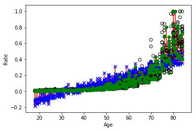

```python
plt.scatter(
    x = X_train.Age,
    y = y_train,
    color = "black",
    facecolor = "none")
plt.scatter(
    x = X_test.Age,
    y = multiple_predictions,
    color = "blue",
    marker = 'x')
plt.scatter(
    x = X_test.Age,
    y = y_test,
    color = "green")
plt.plot(
    [X_test.Age, X_test.Age],
    [multiple_predictions, y_test],
    color = "red",
    zorder = 0)
plt.xlabel("Age")
plt.ylabel("Rate")
plt.show()
```

7. Question: How do you interpret this graph?

8. Compute the root mean squared error (RMSE) of these predictions.

```python
multiple_rmse = np.sqrt(np.mean((y_test - multiple_predictions) ** 2))

print(multiple_rmse)
```

```
0.11691051667329788
```

9. Question: Is this a better predictive model of the data?

### 7. Predict with a Neural Network Regressor

1. Import the standard scaler from sklearn.

```python
from sklearn.preprocessing import StandardScaler
```

2. Create standard scalers for training and test data.

```python
X_scaler = StandardScaler()
y_scaler = StandardScaler()
```

```python
X_scaler.fit(X)
y_scaler.fit(y.values.reshape(-1, 1))
```

```
StandardScaler(copy=True, with_mean=True, with_std=True)
```

4. Scale the training and test data.

```python
X_train_scaled = X_scaler.transform(X_train)
X_test_scaled = X_scaler.transform(X_test)
y_train_scaled = y_scaler.transform(y_train.values.reshape(-1, 1))
y_test_scaled = y_scaler.transform(y_test.values.reshape(-1, 1))
```

5. Import the neural network regressor class from sklearn.

```python
from sklearn.neural_network import MLPRegressor
```

6. Create a neural network regressor with 4 hidden nodes, a tanh activation function, an LBFGS solver, and 1000 maximum iterations.

```python
neural_model = MLPRegressor(
    hidden_layer_sizes = (4),
    activation = "tanh",
    solver = "lbfgs",
    max_iter = 1000)
```

7. Train the model with the training set.

```python
neural_model.fit(
    X = X_train_scaled,
    y = y_train_scaled.reshape(-1, ))
```

```
MLPRegressor(activation='tanh', alpha=0.0001, batch_size='auto', beta_1=0.9,
       beta_2=0.999, early_stopping=False, epsilon=1e-08,
       hidden_layer_sizes=4, learning_rate='constant',
       learning_rate_init=0.001, max_iter=1000, momentum=0.9,
       nesterovs_momentum=True, power_t=0.5, random_state=None,
       shuffle=True, solver='lbfgs', tol=0.0001, validation_fraction=0.1,
       verbose=False, warm_start=False)
```

8. Predict output values for the test set.

```python
scaled_predictions = neural_model.predict(X_test_scaled)
```

9. Unscale the predictions.

```python
neural_predictions = y_scaler.inverse_transform(scaled_predictions)
```

10. Visualize the prediction error.

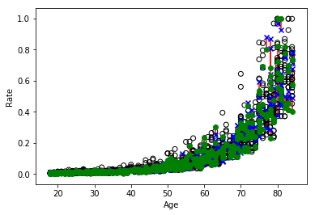

```python
plt.scatter(
    x = X_train.Age,
    y = y_train,
    color = "black",
    facecolor = "none")
plt.scatter(
    x = X_test.Age,
    y = neural_predictions,
    color = "blue",
    marker = 'x')
plt.scatter(
    x = X_test.Age,
    y = y_test,
    color = "green")
plt.plot(
    [X_test.Age, X_test.Age],
    [neural_predictions, y_test],
    color = "red",
    zorder = 0)
plt.xlabel("Age")
plt.ylabel("Rate")
plt.show()
```

11. Compute the root mean squared error (RMSE) of these predictions.

```python
neural_rmse = np.sqrt(np.mean((y_test - neural_predictions) ** 2))
```

12. Inspect the RMSE of these predictions.

```python
print(neural_rmse)
```

```
0.03612720419871486
```

### 8. Evaluate the Regressors

1. Compare all three results.

```python
print("Simple RMSE:   ", simple_rmse)
print("Multiple RMSE: ", multiple_rmse)
print("Neural RMSE:   ", neural_rmse)
```

```
Simple RMSE:    0.12079653135112772
Multiple RMSE:  0.11691051667329788
Neural RMSE:    0.03612720419871486
```

2. Question: Which of these models would you choose? Why?